# Foreign-Connected PAC Contributions

```r
library(tidyverse)
library(janitor)
```

## a. Load all data

Read all 13 CSVs in a single `read_csv()` call, using the file name to derive the election cycle `year` (the second year in each file’s cycle label, e.g. 1999-2000 → 2000).

```r
pac_raw <- read_csv(
  list.files("data", pattern = "\\.csv$", full.names = TRUE),
  id = "source"
) |>
  mutate(
    year = parse_number(str_extract(source, "\\d{4}(?=\\.csv$)")),
    .keep = "unused"
  )
pac_raw
```

```
# A tibble: 2,639 × 6
   `PAC Name (Affiliate)`        Country of Origin/Pa…¹ Total Dems  Repubs  year
   <chr>                         <chr>                  <chr> <chr> <chr>  <dbl>
 1 7-Eleven                      Japan/Ito-Yokado       $8,5… $1,5… $7,000  2000
 2 ABB Group                     Switzerland/Asea Brow… $46,… $17,… $28,5…  2000
 3 Accenture                     UK/Accenture plc       $75,… $23,… $52,9…  2000
 4 ACE INA                       UK/ACE Group           $38,… $12,… $26,0…  2000
 5 Acuson Corp (Siemens AG)      Germany/Siemens AG     $2,0… $2,0… $0      2000
 6 Adtranz (DaimlerChrysler)     Germany/DaimlerChrysl… $10,… $10,… $500    2000
 7 AE Staley Manufacturing (Tat… UK/Tate & Lyle         $24,… $10,… $14,0…  2000
 8 AEGON USA (AEGON NV)          Netherlands/Aegon NV   $58,… $10,… $47,7…  2000
 9 AIM Management Group          UK/AMVESCAP            $25,… $10,… $15,0…  2000
10 Air Liquide America           France/L'Air Liquide … $0    $0    $0      2000
# ℹ 2,629 more rows
# ℹ abbreviated name: ¹`Country of Origin/Parent Company`
```

## b. Clean names and transform

Clean variable names with `janitor::clean_names()`, split `country_of_origin_parent_company` into separate `country_of_origin` and `parent_company` columns, and convert the dollar-string amount columns to numeric.

```r
pac <- pac_raw |>
  clean_names() |>
  separate(
    country_of_origin_parent_company,
    into = c("country_of_origin", "parent_company"),
    sep = "/",
    extra = "merge"
  ) |>
  mutate(
    across(c(total, dems, repubs), ~ parse_number(.x))
  ) |>
  select(year, everything())

pac |> slice_head(n = 10)
```

```
# A tibble: 10 × 7
    year pac_name_affiliate  country_of_origin parent_company total  dems repubs
   <dbl> <chr>               <chr>             <chr>          <dbl> <dbl>  <dbl>
 1  2000 7-Eleven            Japan             Ito-Yokado      8500  1500   7000
 2  2000 ABB Group           Switzerland       Asea Brown Bo… 46000 17000  28500
 3  2000 Accenture           UK                Accenture plc  75984 23000  52984
 4  2000 ACE INA             UK                ACE Group      38500 12500  26000
 5  2000 Acuson Corp (Sieme… Germany           Siemens AG      2000  2000      0
 6  2000 Adtranz (DaimlerCh… Germany           DaimlerChrysl… 10500 10000    500
 7  2000 AE Staley Manufact… UK                Tate & Lyle    24000 10000  14000
 8  2000 AEGON USA (AEGON N… Netherlands       Aegon NV       58250 10500  47750
 9  2000 AIM Management Gro… UK                AMVESCAP       25000 10000  15000
10  2000 Air Liquide America France            L'Air Liquide…     0     0      0
```

## c. Pivot longer

Pivot so `dems`/`repubs` become a `party` column (`Democrat`/`Republican`) and an `amount` column.

```r
pac_long <- pac |>
  pivot_longer(
    cols = c(dems, repubs),
    names_to = "party",
    values_to = "amount"
  ) |>
  mutate(party = recode(party, dems = "Democrat", repubs = "Republican")) |>
  select(-total)

pac_long |> slice_head(n = 10)
```

```
# A tibble: 10 × 6
    year pac_name_affiliate       country_of_origin parent_company  party amount
   <dbl> <chr>                    <chr>             <chr>           <chr>  <dbl>
 1  2000 7-Eleven                 Japan             Ito-Yokado      Demo…   1500
 2  2000 7-Eleven                 Japan             Ito-Yokado      Repu…   7000
 3  2000 ABB Group                Switzerland       Asea Brown Bov… Demo…  17000
 4  2000 ABB Group                Switzerland       Asea Brown Bov… Repu…  28500
 5  2000 Accenture                UK                Accenture plc   Demo…  23000
 6  2000 Accenture                UK                Accenture plc   Repu…  52984
 7  2000 ACE INA                  UK                ACE Group       Demo…  12500
 8  2000 ACE INA                  UK                ACE Group       Repu…  26000
 9  2000 Acuson Corp (Siemens AG) Germany           Siemens AG      Demo…   2000
10  2000 Acuson Corp (Siemens AG) Germany           Siemens AG      Repu…      0
```

## d. UK-connected PAC totals by year and party

```r
uk_contributions <- pac_long |>
  filter(country_of_origin == "UK") |>
  summarise(total_amount = sum(amount, na.rm = TRUE), .by = c(year, party)) |>
  arrange(year, party)

uk_contributions |> slice_head(n = 10)
```

```
# A tibble: 10 × 3
    year party      total_amount
   <dbl> <chr>             <dbl>
 1  2000 Democrat         984725
 2  2000 Republican      2058518
 3  2002 Democrat        1053433
 4  2002 Republican      2003272
 5  2004 Democrat        1206201
 6  2004 Republican      2327001
 7  2006 Democrat        1664491
 8  2006 Republican      3128235
 9  2008 Democrat        2690413
10  2008 Republican      2842956
```

## e. Visualization

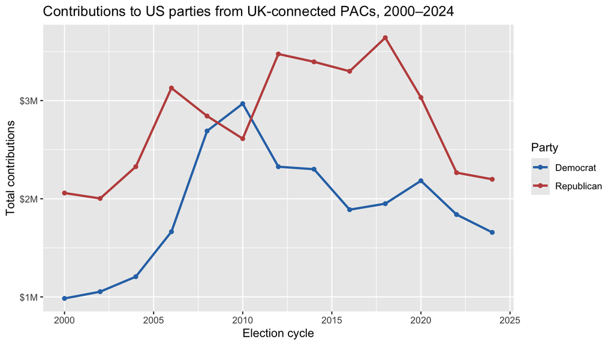

```r
ggplot(uk_contributions, aes(x = year, y = total_amount, color = party)) +
  geom_line(linewidth = 1) +
  geom_point() +
  scale_color_manual(values = c(Democrat = "#2E74B5", Republican = "#C0504D")) +
  scale_y_continuous(
    labels = scales::label_dollar(scale = 1e-6, suffix = "M")
  ) +
  labs(
    x = "Election cycle",
    y = "Total contributions",
    color = "Party",
    title = "Contributions to US parties from UK-connected PACs, 2000–2024"
  )
```

**Design choices:** A line plot is appropriate here because contributions are tracked over time — lines emphasize trends and changes across election cycles better than bars would for a continuous total. Points mark the actual cycle observations. Party is mapped to color using conventional blue/red associations, with direct mapping through `color` rather than facets so the two parties can be compared on the same scale.